# Milestone Report

Soumya Satyakanta Sethi

## Data & R packages

### Required R packages

Before starting the analysis, we load the required R packages.

```r
library(tm)
library(stringi)
library(kableExtra)
library(wordcloud)
library(RColorBrewer)
```

### Accessing the Data

We first downloades the data from the link given in the Coursera **Data Science Capstone** course page and the downloaded .rar file was extracted. Here we assign the path for accessing the data and then we read the data. Here, we read the en_US.blogs.txt, en_US.news.txt and en_US.twitter.txt files.

```r
fpath <- file.path("F:/Coursera_Projects/DataScience_Capstone/final")

#Setting file paths to access the file directly
path_blog <- file.path(fpath,"/en_US/en_US.blogs.txt")
path_news <- file.path(fpath,"/en_US/en_US.news.txt")
path_twitter <- file.path(fpath,"/en_US/en_US.twitter.txt")

#Read in text files
dat_blog <- readLines(path_blog, encoding="UTF-8", skipNul=TRUE)
dat_twitter <- readLines(path_twitter, encoding="UTF-8", skipNul=TRUE)
dat_news <- readLines(path_news, encoding="UTF-8", skipNul=TRUE)
```

## Data Overview

In order to get a sense of what the data looks like, we have summerized the main information from each of the 3 datasets (Blog, News and Twitter). The details are given below.

```r
stats <- data.frame(
  FileName=c("US Blogs","US News","US Twitter"),
  FileSizeinMB=c(file.info(path_blog)$size/1024^2,
                 file.info(path_news)$size/1024^2,
                 file.info(path_twitter)$size/1024^2),
  t(rbind(sapply(list(dat_blog,dat_news,dat_twitter),
                 stri_stats_general),
          WordCount=
            sapply(list(dat_blog,dat_news,dat_twitter),
                   stri_stats_latex)[4,]))
)
kable(stats)
```

| FileName | FileSizeinMB | Lines | LinesNEmpty | Chars | CharsNWhite | WordCount |
| --- | --- | --- | --- | --- | --- | --- |
| US Blogs | 200.4242 | 899288 | 899288 | 206824382 | 170389539 | 37570839 |
| US News | 196.2775 | 77259 | 77259 | 15639408 | 13072698 | 2651432 |
| US Twitter | 159.3641 | 2360148 | 2360148 | 162096241 | 134082806 | 30451170 |

## Sample Data Extraction

As the table above shows, the amount of data in this set is huge. that will need a lot of computation power. Therefore I choose to limit the data.

## Sample Statistics

To get an idea of what tthe data now looks like after extracting the sample, we summerize the statistical information about the data.

```r
Sample_stats <- data.frame(
  FileName=c("Sample US Blogs",
             "Sample US News","Sample US Twitter"),
  t(rbind(sapply(list(sampleBlogs,sampleNews,sampleTwitter),
                 stri_stats_general),
          WordCount=
            sapply(list(sampleBlogs,sampleNews,sampleTwitter),
                   stri_stats_latex)[4,]))
)
kable(Sample_stats)
```

| FileName | Lines | LinesNEmpty | Chars | CharsNWhite | WordCount |
| --- | --- | --- | --- | --- | --- |
| Sample US Blogs | 1798 | 1798 | 416998 | 343413 | 74063 |
| Sample US News | 154 | 154 | 29985 | 24986 | 5170 |
| Sample US Twitter | 4720 | 4720 | 321933 | 266270 | 60554 |

## Clean the Data Sample

After reducing the size of each data set that were loaded sampled data is used to create a corpus, and following clean up steps are performed.

```r
removeNonASCII <- function(x) iconv(x, "latin1", "ASCII", sub="")
removeURL <- function(x) gsub("http[[:alnum:]]*","",x)
removeapo <- function(x) gsub("'","",x)
removeSplChar <-
  function(x) gsub("/|@|//|$|:|:)|*|&|!|?|_|-|#|","",x)

building.corpus <- function (x = Data_subset) {
  corpus <- VCorpus(VectorSource(Data_subset))
  corpus <- tm_map(corpus, removeNonASCII)
  corpus <- tm_map(corpus, removeURL)
  corpus <- tm_map(corpus, removeapo)
  corpus <- tm_map(corpus, removeSplChar)
  corpus <- tm_map(corpus, tolower)
  corpus <- tm_map(corpus, removePunctuation)
  corpus <- tm_map(corpus, removeNumbers)
  corpus <- tm_map(corpus, removeWords,stopwords("english"))
  corpus <- tm_map(corpus, removeWords,c("the", "will", "The",
                   "also", "that", "and", "for",
                   "in", "is", "it", "not", "to"))
  corpus <- tm_map(corpus, stripWhitespace)
  corpus <- tm_map(corpus, PlainTextDocument)
}
fsample <- building.corpus(Data_subset)
```

## Exploratory Analysis

To examine the data, we will produce a word clouds showing frequently used terms in the datasets. The word clouds show generally the top words with size varying by frequency.

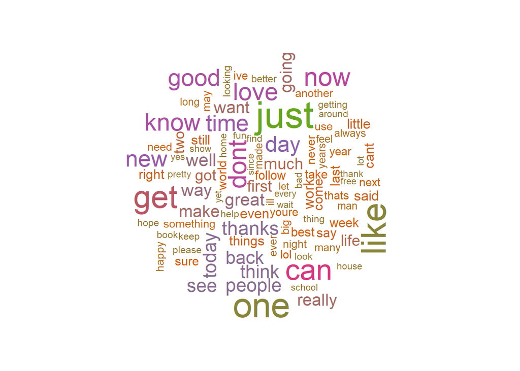

```r
wordcloud(fsample, max.words=100, random.order=TRUE,
          rot.per=.15,
          colors=colorRampPalette(brewer.pal(5,"Dark2"))(32),
          scale=c(3, .3))
```

Further. to visualise the frequency of different words in the sample, we made a distribution plot of the words.

```r
tdm <- TermDocumentMatrix(fsample)
tdm_mat <- as.matrix(tdm)
tdmfreq <- sort(rowSums(tdm_mat), decreasing = TRUE)
```

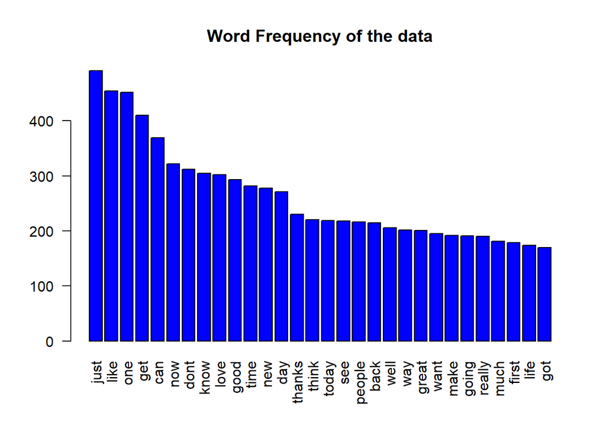

```r
barplot(tdmfreq[1:30],
        col = "blue", las = 2,
        main = "Word Frequency of the data")
```